# Inbreeding management model

Emma Ochsner

# Introduction

This is the R code for my Inbreeding management model. I used SLiM to generate data and R to then analyze it.

## Generating Data in SLiM with Parameters from R - model 1 with non-random mating selecting for not related

Analyzing the output files from SLiM model 1 with non-random mating selecting for not related

```r
#setwd("~/Documents/GitHub/2502_emma_bsc/Outputs/") #setting the working directory
getwd()  # Prints the current working directory
```

```
[1] "/Users/benutzerin/Documents/GitHub/2502_emma_bsc"
```

```r
## all SLiM output files which shiw nonrandom mating with mate choice for least relatedness
slim_out_files <- list.files(pattern = "_nonrandom_notrelated_")

length(slim_out_files)
```

```
[1] 20
```

```r
#install.packages("hierfstat")
library("hierfstat")

## make a dataframe to collect results
## each row in the dataframe corresponds to the results from a single SLiM simulation run

row_numbers <- seq(100001, 100991, by = 20)
#row_names <- paste(row_numbers, "reps", "seed", sep = ";")

results_df_nrnr <- matrix(NA ,nrow = length(slim_out_files), ncol = (length(row_numbers) + 2))
colnames(results_df_nrnr) <- c(row_numbers,"reps","seed")
length(c(row_numbers,"reps","seed"))
```

```
[1] 52
```

```r
dim(results_df_nrnr)
```

```
[1] 20 52
```

```r
for(i in 1:length(slim_out_files)){

  single_file <- slim_out_files[i] ## this is the name of a single SLiM result file
  get_the_reps <- as.numeric(gsub(".*_reps_([0-9]+)_.*", "\\1", single_file))  ## use gsub() to get the value of 'reps' that we saved in the name of the results file
  get_the_seed <- as.numeric(gsub(".*_seed =|\\.csv","",single_file)) ## and for the seed....

  results_df_nrnr[i,"reps"] <- get_the_reps ## record the value of 'r' for this particular results file
  #.*_reps_ → Matches everything before _reps_
  #([0-9]+) → Captures one or more digits (the reps number)
  #_.* → Matches everything after the number (so it gets removed)
  #"\\1" → Extracts only the number inside ().

  results_df_nrnr[i,"seed"] <- get_the_seed ## record the seed for this particular results file

  # Read the CSV file, ensure that it recognizes the header
  df <- read.csv(single_file, header = TRUE)

  # Ensure the column names are correct
  colnames(df) <- c("cycle", "Heterozygosity")

  # Match cycle numbers to the matrix column names
  matched_indices <- match(as.character(df$cycle), colnames(results_df_nrnr))

  # Assign heterozygosity values to the correct positions in results_df_nrnr
  results_df_nrnr[i, matched_indices] <- df$Heterozygosity

}

# Calculate column means (excluding the last two columns: "reps" and "seed")
column_means <- colMeans(results_df_nrnr[, 1:(ncol(results_df_nrnr)-2)], na.rm = TRUE)
# Create a new row with NA for "reps" and "seed" columns
mean_row <- c(column_means, NA, NA)
# Bind the new row to the bottom of results_df_nrnr
results_df_nrnr <- rbind(results_df_nrnr, mean_row)
# Assign row names
rownames(results_df_nrnr)[nrow(results_df_nrnr)] <- "Mean"

# Print the final matrix with the mean row
print(results_df_nrnr)
```

```
          100001      100021      100041      100061      100081      100101      100121
     0.003741890 0.002528590 0.002431600 0.002455440 0.002531510 0.002474210 0.002487160
     0.003825350 0.003407320 0.003399470 0.003276820 0.003282700 0.003097770 0.002942300
     0.003740800 0.002997080 0.002766320 0.002630860 0.002616060 0.002510380 0.002408700
     0.003795090 0.002523790 0.002481300 0.002461740 0.002514950 0.002416740 0.002272180
     0.003880190 0.002320950 0.002680410 0.002749750 0.002806040 0.002732890 0.002729730
     0.003650870 0.003286320 0.003341810 0.003235030 0.003281310 0.003328030 0.003201010
     0.003800190 0.003067070 0.002359610 0.001689480 0.001977860 0.002368490 0.002458050
     0.003652750 0.002793970 0.002062870 0.001785660 0.001976850 0.002095980 0.002181910
     0.003598410 0.002761920 0.002348070 0.002459710 0.002353020 0.001941790 0.001761500
     0.003744500 0.002440090 0.002743210 0.002621290 0.002552470 0.002588620 0.002651690
     0.003754260 0.002982870 0.003132600 0.003147750 0.003131830 0.003195510 0.003079370
     0.003684620 0.002181430 0.002343680 0.002420970 0.002385980 0.002169770 0.002081800
     0.003811890 0.002834500 0.002815810 0.002692000 0.002763430 0.002780920 0.002807930
     0.003907350 0.002905770 0.002614610 0.002875450 0.002905370 0.002875530 0.003032990
     0.003757770 0.002337850 0.001326360 0.001425520 0.001211700 0.001057690 0.000995933
     0.003858860 0.003476970 0.003340910 0.003136320 0.003015420 0.003053830 0.002929440
     0.003760950 0.002165640 0.002453760 0.002233630 0.002210550 0.001944750 0.001815390
     0.003807470 0.002555960 0.002254900 0.002308450 0.002298940 0.002220390 0.002229460
     0.003772040 0.002919020 0.003005210 0.002881090 0.002782750 0.002894520 0.002757700
          100141      100161     100181      100201     100221      100241      100261      100281
     0.002342940 0.002396050 0.00232178 0.002220100 0.00213632 0.002133680 0.002217870 0.002197980
     0.002966590 0.002974090 0.00301729 0.002754850 0.00277664 0.002966640 0.002949140 0.002999860
     0.002633540 0.002535570 0.00256380 0.002291510 0.00227061 0.002010050 0.001888800 0.001764160
     0.002398750 0.002414730 0.00240437 0.002422130 0.00239467 0.002482400 0.002392460 0.002468500
     0.002800820 0.002803900 0.00270290 0.002776770 0.00274402 0.002646830 0.002780230 0.002738920
     0.003373680 0.003234960 0.00309309 0.003116200 0.00293740 0.002859080 0.002925250 0.002872520
     0.002608630 0.002730170 0.00272019 0.002764500 0.00271579 0.002800660 0.002709850 0.002727440
     0.002298690 0.002565750 0.00254032 0.002535460 0.00247406 0.002528580 0.002564990 0.002584460
     0.001740720 0.001605190 0.00145980 0.001238230 0.00119637 0.001300320 0.001249350 0.001400600
     0.002618870 0.002450470 0.00246675 0.002419580 0.00239187 0.002431740 0.002283370 0.002269220
     0.003133900 0.003192900 0.00318506 0.003028860 0.00297149 0.002814250 0.002669180 0.002609930
     0.002000710 0.001990950 0.00199049 0.001921370 0.00192642 0.001894620 0.002077150 0.001835840
     0.002829540 0.002739190 0.00273205 0.002768030 0.00278243 0.002736850 0.002739860 0.002761720
     0.003132670 0.003152840 0.00311077 0.003063400 0.00304996 0.002950430 0.002923540 0.002885540
     0.001084730 0.000978721 0.00118505 0.001181020 0.00128626 0.001466140 0.001371680 0.001762130
     0.002591590 0.002545220 0.00247800 0.002582840 0.00249859 0.002678670 0.002750250 0.002893710
     0.002110300 0.001903270 0.00195906 0.001868000 0.00192577 0.001948470 0.001924980 0.002075130
     0.002191990 0.002127700 0.00195276 0.001972050 0.00192885 0.001949820 0.001983840 0.002020720
     0.002839160 0.002915510 0.00288672 0.002880310 0.00295656 0.003061180 0.003080340 0.003169540
```

[output cut: 106 more lines]

```
     8693866641553850368
     8784193068485143552
     7108799793070202880
     2042255803196037888
     8071816047371470848
     7599689111787397120
     8470006114506264576
     4249112455550577152
     5381960939160695808
     4335098617862449664
     2973513155869465600
     2357364781417710592
     2558920204527791104
     8133148197235549184
 [ reached getOption("max.print") -- omitted 2 rows ]
```

```r
write.csv(results_df_nrnr, "Results_nonrandom_notrelated.csv", row.names = F) #write a file with my results
```

Now i have my results stored in a matrix. This makes it easier to analyze the results.

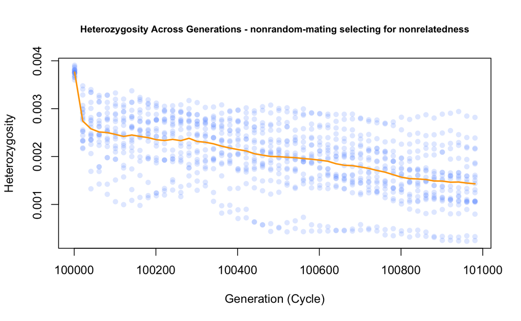

```r
# Extract the cycles (generations) from column names - i dont want the last two entries (seed and reps)
#This will be helpful for the plot
cycle_numbers <- as.numeric(colnames(results_df_nrnr)[1:(ncol(results_df_nrnr)-2)])

# Extract the heterozygosity values (excluding the last row "Mean" and last two columns "reps" & "seed")
heterozygosity_values_nrnr <- results_df_nrnr[1:(nrow(results_df_nrnr)-1), 1:(ncol(results_df_nrnr)-2)]

# Extract the mean heterozygosity values from the last row --> Last row, so we can use nrow
mean_values_nrnr <- results_df_nrnr[nrow(results_df_nrnr), 1:(ncol(results_df_nrnr)-2)]

# Create the plot
matplot(
  cycle_numbers,  # X-axis: Generations
  t(heterozygosity_values_nrnr),  # Transpose to align data correctly
  type = "p",  # "p" for points
  pch = 16,  # Use small dots for points
  col = rgb(0.4, 0.6, 1, 0.2),  # Blue with transparency --> rgb is kind of nice, (red, green, blue, alpha)
  xlab = "Generation (Cycle)",
  ylab = "Heterozygosity",
  main = "Heterozygosity Across Generations - nonrandom-mating selecting for nonrelatedness",
  cex.main = 0.8  # Makes title smaller
)

# Add the mean line
lines(cycle_numbers, mean_values_nrnr, col = "orange", lwd = 2)  # Red solid line
```

```r
NA
NA
NA
```

## Generating Data in SLiM with Parameters from R - model 1 with non-random mating selecting for relatedness

Analyzing the output files from SLiM model 1 with non-random mating selecting for relatedness

```r
#setwd("~/Documents/GitHub/2502_emma_bsc/Outputs/") #setting the working directory
getwd()  # Prints the current working directory
```

```
[1] "/Users/benutzerin/Documents/GitHub/2502_emma_bsc"
```

```r
## all SLiM output files which shiw nonrandom mating with mate choice for least relatedness
slim_out_files <- list.files(pattern = "_nonrandom_related_")

length(slim_out_files)
```

```
[1] 20
```

```r
#install.packages("hierfstat")
library("hierfstat")

## make a dataframe to collect results
## each row in the dataframe corresponds to the results from a single SLiM simulation run

row_numbers <- seq(100001, 100991, by = 20) #this will help me create the columns i need in my matrix
#row_names <- paste(row_numbers, "reps", "seed", sep = ";")

results_df_nrr <- matrix(NA ,nrow = length(slim_out_files), ncol = (length(row_numbers) + 2))
colnames(results_df_nrr) <- c(row_numbers,"reps","seed")
length(c(row_numbers,"reps","seed"))
```

```
[1] 52
```

```r
dim(results_df_nrr)
```

```
[1] 20 52
```

```r
for(i in 1:length(slim_out_files)){

  single_file <- slim_out_files[i] ## this is the name of a single SLiM result file
  get_the_reps <- as.numeric(gsub(".*_reps_([0-9]+)_.*", "\\1", single_file))  ## use gsub() to get the value of 'reps' that we saved in the name of the results file
  get_the_seed <- as.numeric(gsub(".*_seed =|\\.csv","",single_file)) ## and for the seed....

  results_df_nrr[i,"reps"] <- get_the_reps ## record the value of 'r' for this particular results file
  #.*_reps_ → Matches everything before _reps_
  #([0-9]+) → Captures one or more digits (the reps number)
  #_.* → Matches everything after the number (so it gets removed)
  #"\\1" → Extracts only the number inside ().

  results_df_nrr[i,"seed"] <- get_the_seed ## record the seed for this particular results file

  # Read the CSV file, ensure that it recognizes the header
  df <- read.csv(single_file, header = TRUE)

  # Ensure the column names are correct
  colnames(df) <- c("cycle", "Heterozygosity")

  # Match cycle numbers to the matrix column names
  matched_indices <- match(df$cycle, colnames(results_df_nrr))

  # Assign heterozygosity values to the correct positions in results_df_nrr
  results_df_nrr[i, matched_indices] <- df$Heterozygosity

}

# Calculate column means (excluding the last two columns: "reps" and "seed")
column_means <- colMeans(results_df_nrr[, 1:(ncol(results_df_nrr)-2)], na.rm = TRUE)
# Create a new row with NA for "reps" and "seed" columns
mean_row <- c(column_means, NA, NA)
# Bind the new row to the bottom of results_df_nrr
results_df_nrr <- rbind(results_df_nrr, mean_row)
# Assign row names
rownames(results_df_nrr)[nrow(results_df_nrr)] <- "Mean"

# Print the final matrix with the mean row
print(results_df_nrr)
```

```
          100001        100021        100041        100061        100081        100101       100121
     0.003696590 0.00229596000 0.00056972700 0.00094643700 0.00079976400 0.00041969300 0.0005983920
     0.003682680 0.00210842000 0.00221576000 0.00226475000 0.00150350000 0.00137261000 0.0010452000
     0.003723880 0.00009366750 0.00000418873 0.00000948588 0.00001333140 0.00002008890 0.0000253649
     0.003701610 0.00124976000 0.00232546000 0.00231094000 0.00226651000 0.00232692000 0.0020400100
     0.003772870 0.00010355100 0.00000325633 0.00000603403 0.00000755986 0.00001191950 0.0000164674
     0.003747610 0.00230391000 0.00209384000 0.00227615000 0.00235579000 0.00210686000 0.0020907100
     0.003461020 0.00154862000 0.00198207000 0.00168200000 0.00165309000 0.00186284000 0.0020376300
     0.003521370 0.00009962610 0.00000372850 0.00000647705 0.00000595644 0.00000885359 0.0000082150
     0.003570830 0.00077277200 0.00188837000 0.00155363000 0.00137104000 0.00067723700 0.0011586700
     0.003739530 0.00277078000 0.00163449000 0.00150456000 0.00123036000 0.00051882100 0.0009281960
     0.003782010 0.00163419000 0.00161933000 0.00153485000 0.00163245000 0.00153093000 0.0012431200
     0.003708770 0.00208341000 0.00103128000 0.00082928100 0.00088961700 0.00116342000 0.0011300700
     0.003692370 0.00276774000 0.00224121000 0.00191676000 0.00138053000 0.00058390100 0.0011426500
     0.003814310 0.00201175000 0.00146847000 0.00185586000 0.00140544000 0.00140467000 0.0012256900
     0.003701490 0.00232821000 0.00217363000 0.00216954000 0.00218119000 0.00219778000 0.0022359300
     0.003736070 0.00248456000 0.00125602000 0.00177015000 0.00176028000 0.00160148000 0.0017252200
     0.003504780 0.00285232000 0.00221627000 0.00207917000 0.00214586000 0.00223008000 0.0022753400
     0.003532340 0.00090613500 0.00139150000 0.00129985000 0.00117769000 0.00120792000 0.0012762600
     0.003564380 0.00000547255 0.00000670154 0.00001055690 0.00001412520 0.00001671540 0.0000174776
           100141       100161       100181       100201       100221       100241       100261
     0.0009302120 0.0002961370 0.0000151315 0.0000172250 0.0000223086 0.0000227677 0.0000241714
     0.0010771600 0.0014561900 0.0010372500 0.0005876750 0.0005481570 0.0005247120 0.0003709350
     0.0000284775 0.0000313721 0.0000312883 0.0000257376 0.0000254665 0.0000308572 0.0000398260
     0.0023345300 0.0019745500 0.0016685900 0.0020121800 0.0017699400 0.0005867570 0.0004622490
     0.0000204331 0.0000242930 0.0000290746 0.0000328032 0.0000287719 0.0000257433 0.0000274337
     0.0022536700 0.0021566400 0.0022056900 0.0022414800 0.0022945700 0.0018418800 0.0012970900
     0.0020418000 0.0015002600 0.0015730200 0.0017241900 0.0016626100 0.0018221000 0.0019091700
     0.0000165929 0.0000159914 0.0000156733 0.0000188186 0.0000304323 0.0000293563 0.0000329833
     0.0012040400 0.0020698500 0.0020704300 0.0020694100 0.0020858800 0.0020819700 0.0020002500
     0.0009235860 0.0010556800 0.0004380160 0.0000395732 0.0000249230 0.0000303242 0.0000335554
     0.0014996500 0.0014884600 0.0015546000 0.0014032700 0.0016340000 0.0015202500 0.0016656900
     0.0010577000 0.0009777440 0.0011206600 0.0011332100 0.0007843270 0.0006024270 0.0007326100
     0.0013687800 0.0012443800 0.0013711900 0.0010552500 0.0010654200 0.0014282800 0.0011516000
     0.0011341300 0.0009675420 0.0003364030 0.0003214260 0.0005880410 0.0003123150 0.0002045000
     0.0022875600 0.0023411100 0.0022277800 0.0018040800 0.0016219200 0.0016872600 0.0014440200
     0.0019694700 0.0011518000 0.0007960230 0.0007190240 0.0004954490 0.0004165800 0.0004520710
     0.0024739100 0.0024974300 0.0023919800 0.0023906900 0.0024766100 0.0024391200 0.0023947300
     0.0012432900 0.0012223300 0.0012606900 0.0010788900 0.0009984480 0.0011412400 0.0009306590
     0.0000193790 0.0000262020 0.0000273307 0.0000253309 0.0000296895 0.0000328123 0.0000350236
```

[output cut: 106 more lines]

```
     0.0009196230   14 4560225982994585088
     0.0013180200   15  970883353193010176
     0.0000898297   16 1329851530190463744
     0.0001077750   17 2044079937252659712
     0.0000317270   18 4392320846950830592
     0.0000744191   19 4635743799057003520
     0.0000748114    2 2621965005472523264
     0.0010060000   20  155952541255426464
     0.0000747578    3 2761600226175324672
     0.0000543718    4 7249361530466056192
     0.0000753273    5 1041597843453071488
     0.0000708213    6 1868647283433037056
     0.0000809106    7 6415200595715514368
     0.0001341840    8 1117974694163442432
 [ reached getOption("max.print") -- omitted 2 rows ]
```

```r
write.csv(results_df_nrr, "Results_nonrandom_related.csv", row.names = F) #write a file with my results
```

Now i have my results stored in a matrix. This makes it easier to analyze the results.

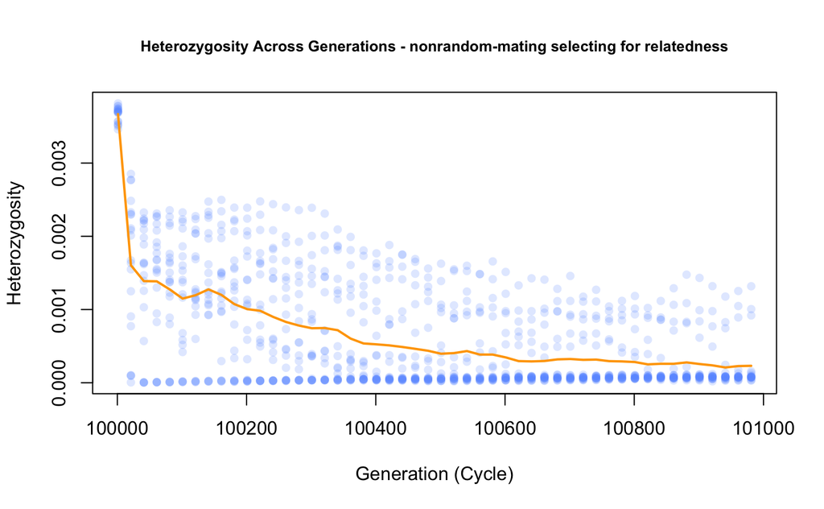

```r
# Extract the cycles (generations) from column names - i dont want the last two entries (seed and reps)
#This will be helpful for the plot
cycle_numbers <- as.numeric(colnames(results_df_nrr)[1:(ncol(results_df_nrr)-2)])

# Extract the heterozygosity values (excluding the last row "Mean" and last two columns "reps" & "seed")
heterozygosity_values_nrr <- results_df_nrr[1:(nrow(results_df_nrr)-1), 1:(ncol(results_df_nrr)-2)]

# Extract the mean heterozygosity values from the last row --> Last row, so we can use nrow
mean_values_nrr <- results_df_nrr[nrow(results_df_nrr), 1:(ncol(results_df_nrr)-2)]

# Create the plot
matplot(
  cycle_numbers,  # X-axis: Generations
  t(heterozygosity_values_nrr),  # Transpose to align data correctly
  type = "p",  # "p" for points
  pch = 16,  # Use small dots for points
  col = rgb(0.4, 0.6, 1, 0.2),  # Blue with transparency --> rgb is kind of nice, (red, green, blue, alpha)
  xlab = "Generation (Cycle)",
  ylab = "Heterozygosity",
  main = "Heterozygosity Across Generations - nonrandom-mating selecting for relatedness",
  cex.main = 0.8  # Makes title smaller
)

# Add the mean line
lines(cycle_numbers, mean_values_nrr, col = "orange", lwd = 2)  # Red solid line
```

```r
NA
NA
NA
```

Now i do exactly the same, but (without any mate choice command in slim). So the mating will be random…

## Generating Data in SLiM with Parameters from R - model 1 with random mating

Analyzing the output files from SLiM model 1 with random mating

```r
#setwd("~/Documents/GitHub/2502_emma_bsc/Outputs/") #setting the working directory
getwd()  # Prints the current working directory
```

```
[1] "/Users/benutzerin/Documents/GitHub/2502_emma_bsc"
```

```r
## all SLiM output files which shiw nonrandom mating with mate choice for least relatedness
slim_out_files <- list.files(pattern = "_random_")

length(slim_out_files)
```

```
[1] 20
```

```r
#install.packages("hierfstat")
library("hierfstat")

## make a dataframe to collect results
## each row in the dataframe corresponds to the results from a single SLiM simulation run

row_numbers <- seq(100001, 100991, by = 20) #this will help me create the columns i need in my matrix
#row_names <- paste(row_numbers, "reps", "seed", sep = ";")

results_df_r <- matrix(NA ,nrow = length(slim_out_files), ncol = (length(row_numbers) + 2))
colnames(results_df_r) <- c(row_numbers,"reps","seed")
length(c(row_numbers,"reps","seed"))
```

```
[1] 52
```

```r
dim(results_df_r)
```

```
[1] 20 52
```

```r
for(i in 1:length(slim_out_files)){

  single_file <- slim_out_files[i] ## this is the name of a single SLiM result file
  get_the_reps <- as.numeric(gsub(".*_reps_([0-9]+)_.*", "\\1", single_file))  ## use gsub() to get the value of 'reps' that we saved in the name of the results file
  get_the_seed <- as.numeric(gsub(".*_seed =|\\.csv","",single_file)) ## and for the seed....

  results_df_r[i,"reps"] <- get_the_reps ## record the value of 'r' for this particular results file
  #.*_reps_ → Matches everything before _reps_
  #([0-9]+) → Captures one or more digits (the reps number)
  #_.* → Matches everything after the number (so it gets removed)
  #"\\1" → Extracts only the number inside ().

  results_df_r[i,"seed"] <- get_the_seed ## record the seed for this particular results file

  # Read the CSV file, ensure that it recognizes the header
  df <- read.csv(single_file, header = TRUE)

  # Ensure the column names are correct
  colnames(df) <- c("cycle", "Heterozygosity")

  # Match cycle numbers to the matrix column names
  matched_indices <- match(df$cycle, colnames(results_df_r))

  # Assign heterozygosity values to the correct positions in results_df_r
  results_df_r[i, matched_indices] <- df$Heterozygosity

}

# Calculate column means (excluding the last two columns: "reps" and "seed")
column_means <- colMeans(results_df_r[, 1:(ncol(results_df_r)-2)], na.rm = TRUE)
# Create a new row with NA for "reps" and "seed" columns
mean_row <- c(column_means, NA, NA)
# Bind the new row to the bottom of results_df_r
results_df_r <- rbind(results_df_r, mean_row)
# Assign row names
rownames(results_df_r)[nrow(results_df_r)] <- "Mean"

# Print the final matrix with the mean row
print(results_df_r)
```

```
          100001      100021      100041      100061      100081      100101      100121
     0.003848430 0.003344630 0.003145160 0.003038890 0.002928990 0.002948950 0.002977810
     0.003708220 0.002794720 0.002823560 0.002872330 0.002784320 0.002810670 0.002730510
     0.003856760 0.003059250 0.002840050 0.002759610 0.002723070 0.002594450 0.002672180
     0.003680240 0.002954430 0.002377190 0.002409320 0.002369250 0.002600260 0.002461460
     0.003710220 0.002464270 0.002194650 0.002280670 0.002223420 0.002024570 0.001953120
     0.003809150 0.002740700 0.002934730 0.002824150 0.002794490 0.002723540 0.002780380
     0.003882090 0.003015460 0.002912690 0.002769210 0.002738950 0.002803580 0.002825490
     0.003713170 0.002809060 0.002647180 0.002451770 0.002234270 0.001965830 0.002056740
     0.003731780 0.002965430 0.003288620 0.003275580 0.003297460 0.003373610 0.003307180
     0.003669130 0.002560510 0.002540380 0.002576980 0.002582750 0.002470060 0.002555130
     0.003761160 0.003316660 0.002904360 0.002937550 0.003046560 0.003097790 0.003024590
     0.003740450 0.003238500 0.002926650 0.002845920 0.002859980 0.002789580 0.002594340
     0.003841520 0.003077980 0.003204220 0.003044290 0.003070040 0.002947500 0.002873210
     0.003815140 0.003115540 0.003186540 0.003206920 0.003154660 0.003051000 0.003035530
     0.003716440 0.003263380 0.002930100 0.002763660 0.002745950 0.002800390 0.002919290
     0.003797510 0.003265630 0.002886440 0.002729960 0.002709520 0.002715670 0.002548470
     0.003774930 0.002776580 0.002310640 0.002345290 0.002290040 0.002348930 0.002408640
     0.003858460 0.002732760 0.002371880 0.002633030 0.002668450 0.002873480 0.002802410
     0.003879880 0.002506910 0.002718250 0.002782140 0.002495270 0.002552210 0.002556590
          100141      100161      100181      100201      100221      100241      100261
     0.003039580 0.002970960 0.002966530 0.002880450 0.002835990 0.002720940 0.002644150
     0.002630140 0.002651400 0.002726170 0.002624620 0.002716230 0.002863500 0.002870120
     0.002831580 0.002645730 0.002531470 0.002545250 0.002493580 0.002493670 0.002439560
     0.002318060 0.002327580 0.002148990 0.002086700 0.001988680 0.001831020 0.002052940
     0.001766050 0.001664060 0.001758710 0.001693970 0.001671100 0.001648550 0.001593960
     0.002664720 0.002560610 0.002549640 0.002456670 0.002543180 0.002541490 0.002518120
     0.002832860 0.002783480 0.002926920 0.002782790 0.002734160 0.002635400 0.002642950
     0.002216650 0.002157410 0.002200080 0.002231900 0.002313380 0.002177280 0.002109730
     0.003290340 0.003356310 0.003413210 0.003468880 0.003449510 0.003470770 0.003428210
     0.002574730 0.002469220 0.002577280 0.002384370 0.002408640 0.002371960 0.002442500
     0.003020420 0.002895670 0.003027120 0.002922850 0.002923420 0.002891070 0.002895510
     0.002372990 0.002223210 0.002472080 0.002661520 0.002777570 0.002654930 0.002756320
     0.002529550 0.002371880 0.002403870 0.002157380 0.002076010 0.001949860 0.001852960
     0.002966510 0.003039070 0.003000110 0.002953270 0.002865220 0.002841040 0.002815970
     0.002835070 0.002833680 0.002848950 0.002881630 0.002899770 0.002893070 0.002849300
     0.002529980 0.002542800 0.002649460 0.002621270 0.002621280 0.002656600 0.002579430
     0.002217570 0.002258640 0.002110390 0.002229370 0.002355360 0.002367320 0.002276390
     0.002841740 0.002776740 0.002659970 0.002535710 0.002513750 0.002534650 0.002550620
     0.002636430 0.002616370 0.002502060 0.002441540 0.002499430 0.002456710 0.002268900
```

[output cut: 86 more lines]

```
     0.002264490 0.00230032 0.002352870 0.002346090 0.002286170   14 8201966278044401664
     0.002004880 0.00201825 0.001999120 0.002018690 0.002001880   15 8670918822437123072
     0.001285670 0.00131413 0.001270580 0.001190500 0.001212260   16 2561600773991191040
     0.002238120 0.00225008 0.002197280 0.002344880 0.002342630   17 7597497744715163648
     0.001692850 0.00161156 0.001571350 0.001489800 0.001454750   18 2751699886084012032
     0.002214020 0.00218180 0.002156840 0.002130460 0.002177430   19 5535909214036902912
     0.001721700 0.00177538 0.001768490 0.001755140 0.001627430    2 7690555130589417472
     0.001385780 0.00144783 0.001472380 0.001500950 0.001611510   20  579734172080167040
     0.002337900 0.00237087 0.002309740 0.002352820 0.002282280    3 2418470276449147904
     0.002267030 0.00222578 0.002243130 0.002156270 0.002116290    4 5463110254092672000
     0.001980660 0.00198605 0.002017820 0.002120710 0.002064480    5 8820510314021171200
     0.002148430 0.00207151 0.002078430 0.002056760 0.002044150    6 7293767864698851328
     0.001858070 0.00188179 0.001858760 0.001781710 0.001732470    7 6270308240323946496
     0.001820050 0.00184421 0.001873570 0.001924900 0.001877810    8 1012572426893761792
 [ reached getOption("max.print") -- omitted 2 rows ]
```

```r
write.csv(results_df_r, "Results_random.csv", row.names = F) #write a file with my results
```

Now i have my results stored in a matrix. This makes it easier to analyze the results.

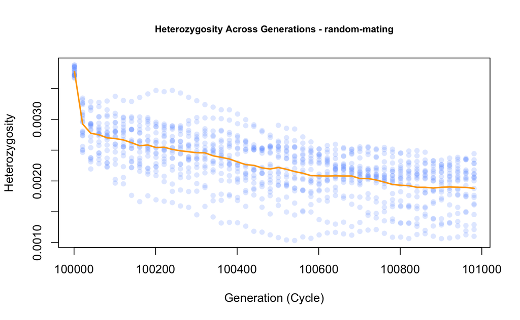

```r
# Extract the cycles (generations) from column names - i dont want the last two entries (seed and reps)
#This will be helpful for the plot
cycle_numbers <- as.numeric(colnames(results_df_r)[1:(ncol(results_df_r)-2)])

# Extract the heterozygosity values (excluding the last row "Mean" and last two columns "reps" & "seed")
heterozygosity_values_r <- results_df_r[1:(nrow(results_df_r)-1), 1:(ncol(results_df_r)-2)]

# Extract the mean heterozygosity values from the last row --> Last row, so we can use nrow
mean_values_r <- results_df_r[nrow(results_df_r), 1:(ncol(results_df_r)-2)]

# Create the plot
matplot(
  cycle_numbers,  # X-axis: Generations
  t(heterozygosity_values_r),  # Transpose to align data correctly
  type = "p",  # "p" for points
  pch = 16,  # Use small dots for points
  col = rgb(0.4, 0.6, 1, 0.2),  # Blue with transparency --> rgb is kind of nice, (red, green, blue, alpha)
  xlab = "Generation (Cycle)",
  ylab = "Heterozygosity",
  main = "Heterozygosity Across Generations - random-mating",
  cex.main = 0.8  # Makes title smaller
)

# Add the mean line
lines(cycle_numbers, mean_values_r, col = "orange", lwd = 2)  # Red solid line
```

```r
NA
NA
NA
```

now i want to combine all the three graphs i just generated into one. This helps me to better compare the outputs…

```r
# Create the plot
matplot(
  cycle_numbers,  # X-axis: Generations
  t((heterozygosity_values_r)),  # Transpose to align data correctly
  type = "p",  # "p" for points
  pch = 16,  # Use small dots for points
  col = rgb(0.4, 0.6, 1, 0.2),  # light Blue with transparency --> rgb is kind of nice, (red, green, blue, alpha)
  xlab = "Generation (Cycle)",
  ylab = "Heterozygosity",
  main = "Heterozygosity Across Generations",
  cex.main = 0.8  # Makes title smaller
)

# Add the mean line
lines(cycle_numbers, (mean_values_r), col = "blue", lwd = 2)  # Red solid line
```

```r
# Now add the other points and lines
# Add non-random selecting for relatedness
matpoints(cycle_numbers, t((heterozygosity_values_nrr)), pch = 16, col = rgb(1, 0.5, 0.5, 0.2))
lines(cycle_numbers, (mean_values_nrr), col = "red", lwd = 2)
```

```r
# add non-rendom selecting for not related
matpoints(cycle_numbers, t((heterozygosity_values_nrnr)), pch = 16, col = rgb(0.4, 1, 0.4, 0.2))
lines(cycle_numbers, mean_values_nrnr, col = "forestgreen", lwd = 2)
```

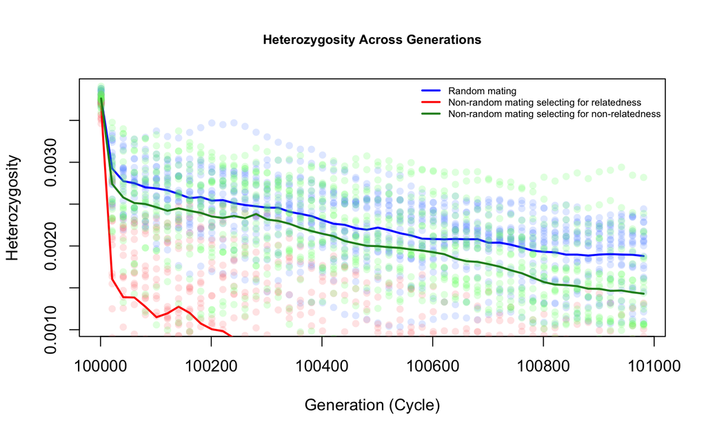

```r
legend("topright", legend = c("Random mating", "Non-random mating selecting for relatedness", "Non-random mating selecting for non-relatedness"), col = c("blue", "red", "forestgreen"), lwd = 2, bty = "n", cex = 0.6)
```

```r
NA
NA
```

Now I do a plot from only the first 100 generations, to see what exactly is happening at the beginning…

```r
heterozygosity_only_nrnr <- heterozygosity_values_nrnr[, 1:length(cycle_numbers)]
heterozygosity_only_nrr <- heterozygosity_values_nrr[, 1:length(cycle_numbers)]
heterozygosity_only_r <- heterozygosity_values_r[, 1:length(cycle_numbers)]
#I did this to cut off the last two columns (seed and rep) --> Due to this, i can then apply the filter (next lines) to the matrix. Otherwise it would not match the dimension of cycle_numbers...


# Filter to only the first 100 generations
cutoff <- 100101
shorting <- cycle_numbers <= cutoff


print(length(cycle_numbers[shorting]))  # Should be > 0
```

```
[1] 6
```

```r
print(dim(t(heterozygosity_only_r)[shorting, ]))  # Should show rows and columns
```

```
[1]  6 20
```

```r
# Create the plot
matplot(
  cycle_numbers[shorting],  # X-axis: Generations, here the filter is active
  t(heterozygosity_only_r)[shorting, ],  # Transpose to align data correctly --> I want to cut the columns not the rows, thats why there is this notation with the ,
  type = "p",  # "p" for points
  pch = 16,  # Use small dots for points
  col = rgb(0.4, 0.6, 1, 0.2),  # light Blue with transparency --> rgb is kind of nice, (red, green, blue, alpha)
  xlab = "Generation (Cycle)",
  ylab = "Heterozygosity",
  main = "Heterozygosity Across Generations",
  cex.main = 0.8,  # Makes title smaller
  log = "y"  # This makes the y-axis logarithmic
)

# Add the mean line
lines(cycle_numbers[shorting], mean_values_r[shorting], col = "blue", lwd = 2)  # Red solid line
```

```r
# Now add the other points and lines
# Add non-random selecting for relatedness
matpoints(cycle_numbers[shorting], t(heterozygosity_only_nrr)[shorting, ], pch = 16, col = rgb(1, 0.5, 0.5, 0.2))
lines(cycle_numbers[shorting], mean_values_nrr[shorting], col = "red", lwd = 2)
```

```r
# add non-rendom selecting for not related
matpoints(cycle_numbers[shorting], t(heterozygosity_only_nrnr)[shorting, ], pch = 16, col = rgb(0.4, 1, 0.4, 0.2))
lines(cycle_numbers[shorting], mean_values_nrnr[shorting], col = "forestgreen", lwd = 2)
```

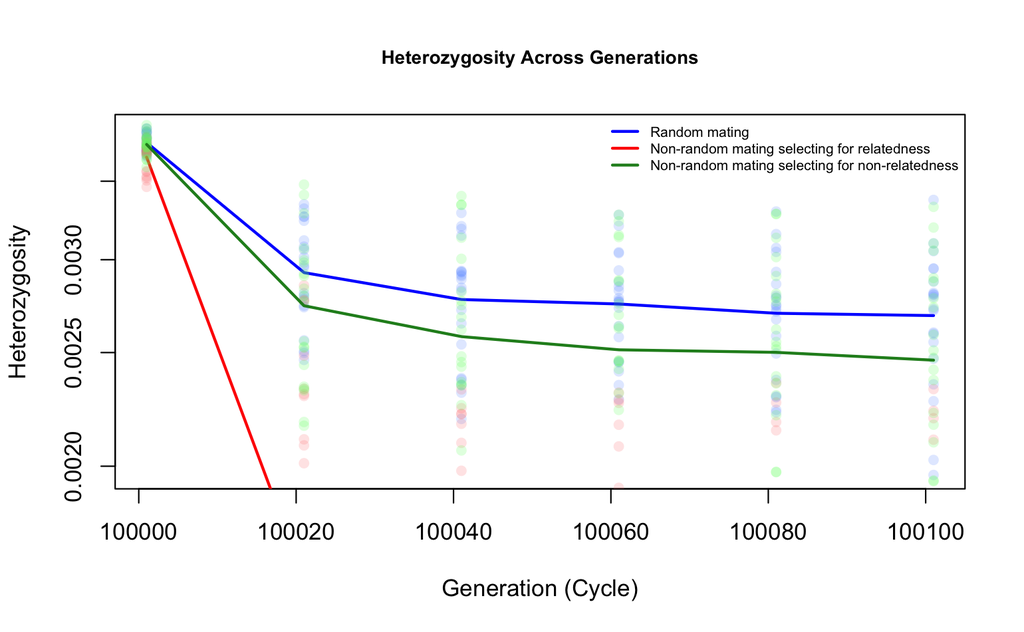

```r
legend("topright", legend = c("Random mating", "Non-random mating selecting for relatedness", "Non-random mating selecting for non-relatedness"), col = c("blue", "red", "forestgreen"), lwd = 2, bty = "n", cex = 0.6)
```

```r
NA
NA
```